# Diabeł Tasmański

Julia super programista

23 maja 2018

### Diabeł Tasmański

[figure not shown]

## Ogólne informację

Diabeł tasmański to gatunek **mięsożernego ssaka**, **torbacza**. Obecnie występuje na wolności jedynie na **australijskiej wyspie Tasmanii**. Osiąga wielkość niewielkiego psa i jest największym współczesnym mięsożernym torbaczem. —

# Cechy charakterystyczne

- krępe i umięśnione ciało,
- czarne futro,
- ostry zapach,
- bardzo głośny i niepokojący pisk,
- doskonały węch,
- charakterystyczny sposób pożywiania się.

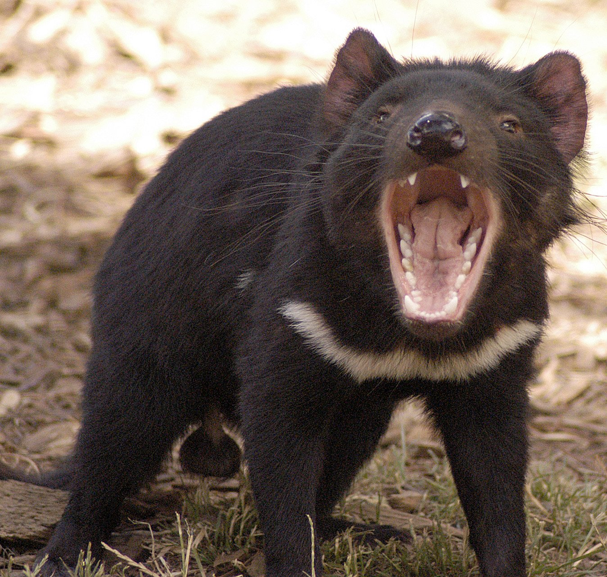

# Co je ten zwierz?

Poluje na zdobycz i poszukuje padliny, zjada też produkty spożywcze, jeśli bytuje w pobliżu osiedli ludzkich.

# Tryb życia

Zazwyczaj prowadzi **samotny** tryb życia, czasami żywi się razem z innymi diabłami i wypróżnia się we wspólnym miejscu. W odróżnieniu od większości niełazowatych, posiada efektywne **mechanizmy termoregulacj**i organizmu, co pozwala mu zachować aktywność w południe, nie przegrzewając się. Pomimo pulchnego wyglądu zaskakuje **szybkością i wytrzymałością**. Potrafi wspinać się na drzewa i przepływać rzeki.

## Diabły tasmańskie a kultura

1. Stanowi symbol Tasmanian National Parks and Wildlife Service.
2. Dawniejszy zespół futbolu w Victorian Football League znany był jako Devils („Diabły”).
3. Zwierzę pojawiło się na kilku pamiątkowych monetach australijskich.
4. Tasmański Cascade Brewery sprzedaje piwo imbirowe z diabłem tasmańskim na etykiecie.
5. Inspiracja dla bohatera kreskówki Looney Tunes Diabła Tasmańskiego, zwanego też „Taz”, który pojawił się w 1954.
6. Superbohater, stworzony przez DC Comics, zwany Tasmanian Devil, wchodzący w skład grupy Global Guardians.

[figure not shown]